# Hypervolume_analyses

Patrick Alexander Walkden

29/10/2021

## Hypervolume Analyses

Following generating the species pool and performing randomisations it’s time to look at how the occupancy of functional trait space as described by the TPD functions is distributed within each land-use and how the structure of this trait space differs across land-use types and compared to null communities.

First, I am going to visualize the structure of occupied trait space across land uses within biogeographic realms

# site distribution

First things first, lets see how the sites that have a TPD calculated for them are distributed across land-uses and biogeographic realms.

```r
 TPD_LU <- data.frame(SSBS = names(PREDICTS_tpds)) %>% dplyr::left_join(PREDICTS) %>% dplyr::filter(Predominant_habitat != "Cannot decice",
                                                                                                    Use_intensity != "Cannot decide")
 table(TPD_LU$Predominant_habitat, TPD_LU$Realm)
```

```
##
##                        Afrotropic Australasia Indo-Malay Nearctic Neotropic
##   Cropland                     71           1         20       18        19
##   Pasture                      15          23          0       28        66
##   Plantation forest            91           3        119        3        34
##   Primary forest              123          25         78       39        82
##   Primary non-forest           41          32          0       47         5
##   Secondary vegetation         93          25         21        0        55
##   Urban                        10          11          4       29        40
##
##                        Palearctic
##   Cropland                     25
##   Pasture                      26
##   Plantation forest           161
##   Primary forest              105
##   Primary non-forest            2
##   Secondary vegetation        120
##   Urban                        30
```

Here we can see that there is quite an uneven spread of sites across the LU types and Realms so to check whether there are enough sites I am going to iteratively calculate functional diversity metrics for each LU-realm combination and if FD reaches an asymptote it will indicate that there are sufficent sites so that trait spaces can be compared.

Now let’s have a look! I have checked all the plot but I am going to exhibit just a couple here

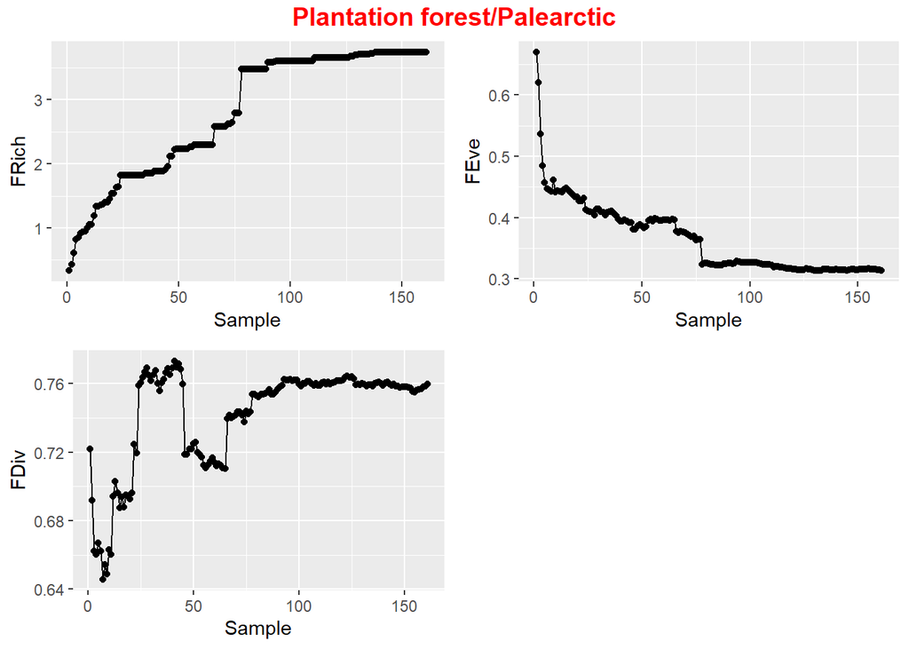

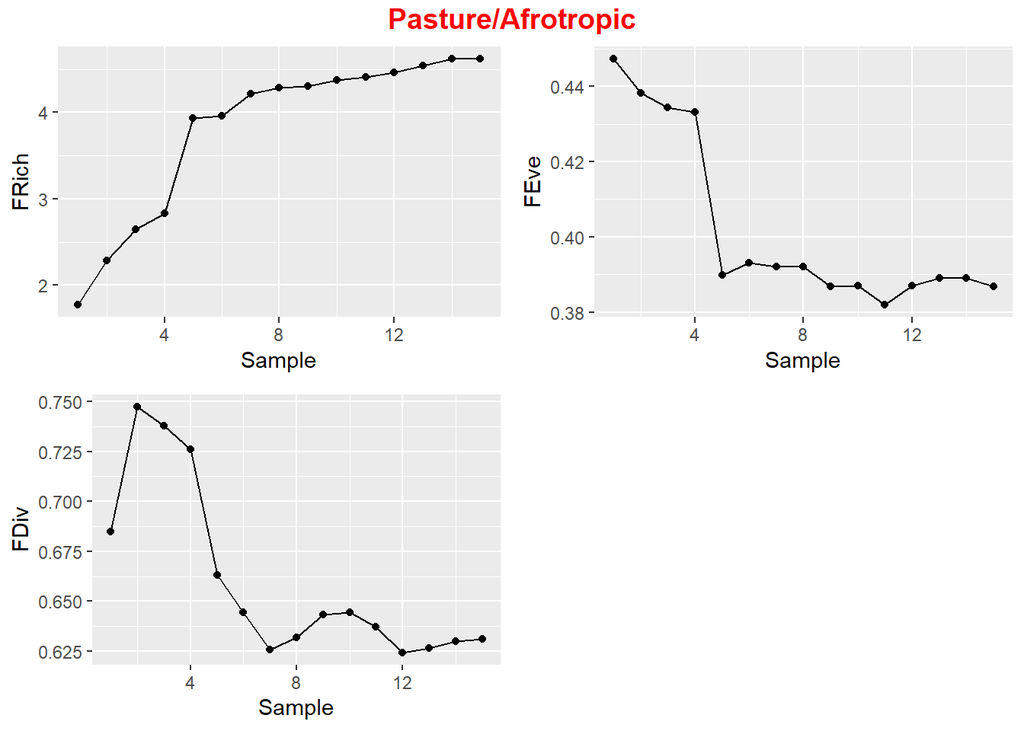

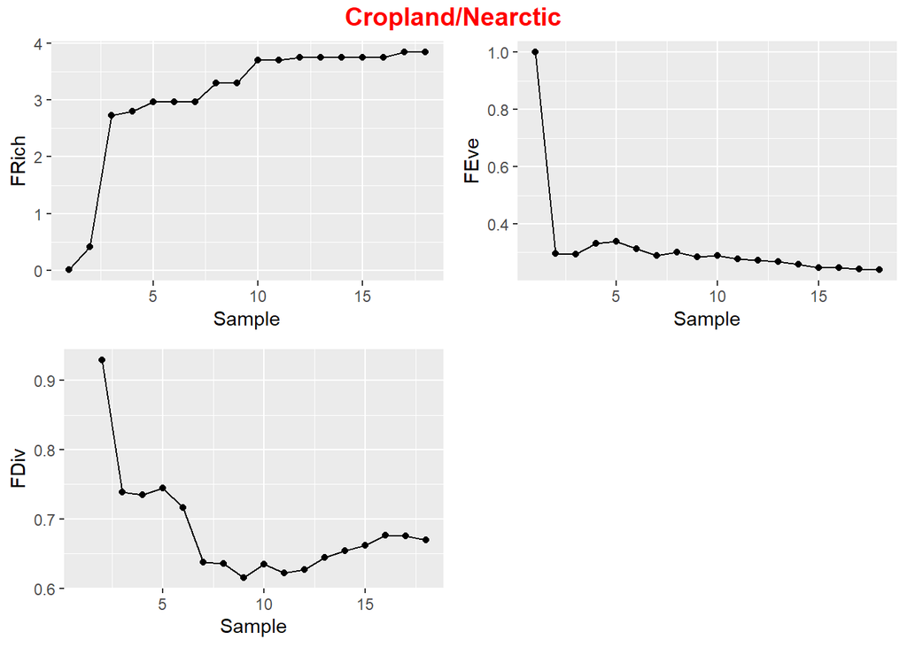

```r
sites <- c(1,11,31)

for(i in sites){
    figure <- Check_list[[i]]$ggplots
    figure <- annotate_figure(figure,
                    top = text_grob(paste(names(Check_list)[i]), color = "red", face = "bold", size = 14))

plot(figure)
}
```

So upon examining the plots there are a good number of LU/realm combinations that have sufficient sites to reasonably represent the occupancy of functional trait space.

Above are some examples of the variety of different patterns produced. Plantation forest in the Palearctic clearly is sufficeintly sampled. Pasture in the Afrotropics. although containing only a few sites does exhibit an asymptote and has been included for now but may need to be dropped later, and finally cropland in the Nearctic which is showing Functional richness is still increasing so therefore has not been sufficeintly sampled and therefore dropped.

So….

In the Afrotropics we can compare Cropland, Pasture, Plantation forest, Primary forest, Primary non-forest and Secondary vegetation.

In Australasia we can compare Pasture, Primary forest, Primary non-forest and Secondary vegetation.

In Indo-Malay we can compare Cropland, Plantation forest, Primary forest, and Secondary vegetation.

Primary forest is the only land-use classification that is well represented ubiquitously across the realms, but there is also good coverage from secondary vegetation, plantation forest, pasture and, maybe, cropland.

Urban and primary non-forest classifications are represented well in only three of the realms… maybe a case for combining primary sites together??

However, for now lets have a look at these trait spaces and use Primary forest sites in the Afrotropics as an example.

```r
pri_afro <- TPD_LU %>% dplyr::filter(Predominant_habitat == "Primary forest", Realm == "Afrotropic") %>% dplyr::distinct(SSBS) %>% pull()

TPD_3d_plot(data = PREDICTS_tpds, sites = pri_afro, T1lab = "Locomotion", T2lab = "Foraging", T3lab = "Body", method = "prob", title = "TPD_test_plot")
```

[interactive chart not shown]

In this plot you can see a 3D plot representing the occupancy of trait space in the three dimensions characterised by our axes of the forgaing, locomotory and body niches.

Scores on the body dimension track the size of the bird.

High scores on the locomotory axis represent long tarsus’ with slight increases in secondary wing lengths, while lower scores indicate longer tails and minor increases in wing length.

The foraging niche is based on the dimensions of the beak and high scores representing wide, deep beaks and as scores decrease beaks tend towards those that are longer and thinner.

It’s all well and good being able to represent these trait spaces but what do they represent and how do they differ across land use gradients within biogeographic realms.

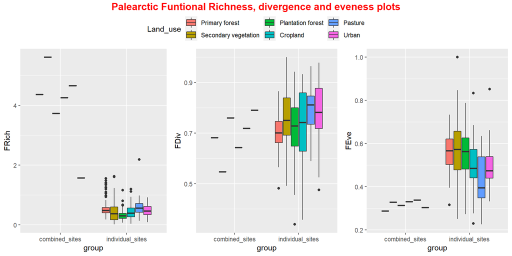

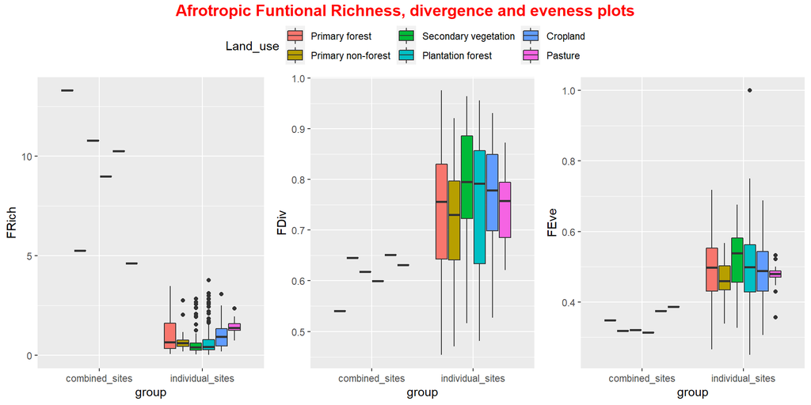

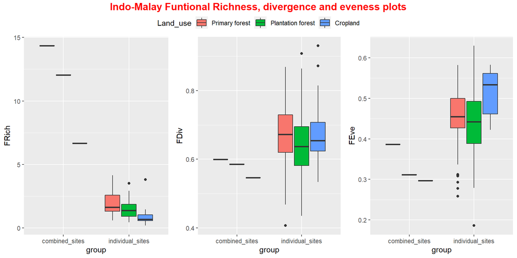

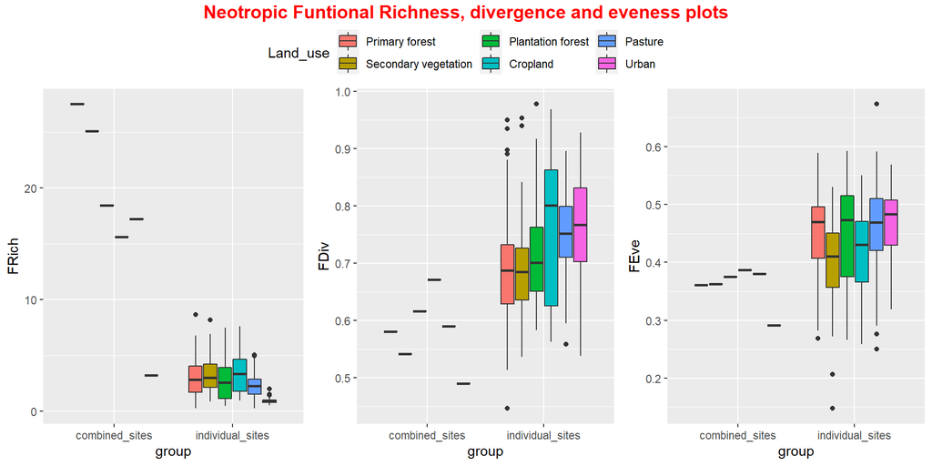

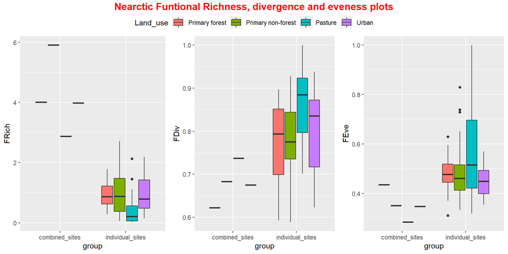

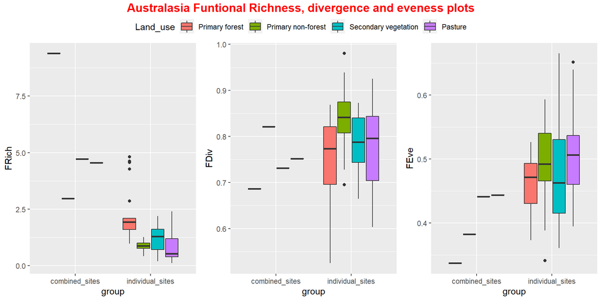

```r
for(r in realms){


      if(r == "Afrotropic"){
      land_uses <- c("Primary forest","Primary non-forest", "Secondary vegetation","Plantation forest","Cropland","Pasture")
    }
    if(r == "Australasia"){
      land_uses <- c("Primary forest","Primary non-forest", "Secondary vegetation", "Pasture")
    }
    if(r == "Indo-Malay"){
      land_uses <- c("Primary forest","Seconday vegetation","Plantation forest","Cropland")
    }
    if(r == "Nearctic"){
      land_uses <- c("Primary forest","Primary non-forest","Pasture", "Urban")
    }
    if(r == "Neotropic"){
      land_uses <- c("Primary forest","Secondary vegetation","Plantation forest","Cropland","Pasture","Urban")
    }
    if(r == "Palearctic"){
      land_uses <- c("Primary forest","Secondary vegetation", "Plantation forest","Cropland","Pasture","Urban")
    }

  plot_data <- c()
  for(LU in land_uses){

  lu_sites <- TPD_LU %>% dplyr::filter(Predominant_habitat == LU, Realm == r) %>% dplyr::distinct(SSBS) %>% pull()

  metrics <- TPD_FD_metrics(data = PREDICTS_tpds, sites = lu_sites)
  metrics$Land_use <- LU
  metrics$group <- "individual_sites"
  metrics$group[nrow(metrics)] <- "combined_sites"
  metrics$group <- factor(metrics$group)
  plot_data <- rbind(plot_data,metrics)
  }

  plot_data$Land_use <- factor(plot_data$Land_use, levels = land_uses)


  p_rich <- ggplot(data = plot_data, aes(x = group, y = FRich)) +
    geom_boxplot(aes(fill = Land_use))

  p_div <- ggplot(data = plot_data, aes(x = group, y = FDiv)) +
    geom_boxplot(aes(fill = Land_use))

  p_eve <- ggplot(data = plot_data, aes(x = group, y = FEve)) +
    geom_boxplot(aes(fill = Land_use))

  p <- ggpubr::ggarrange(p_rich,p_div,p_eve, nrow = 1, common.legend = TRUE)

  p <- annotate_figure(p,
                    top = text_grob(paste(r,"Funtional Richness, divergence and eveness plots"), color = "red", face = "bold", size = 14))
  plot(p)
}
```

## Differences between hypervolumes

Now let’s calculate some beta-diversity metrics between the sites and characterise just how land use change is influencing the structure of functional trait space.

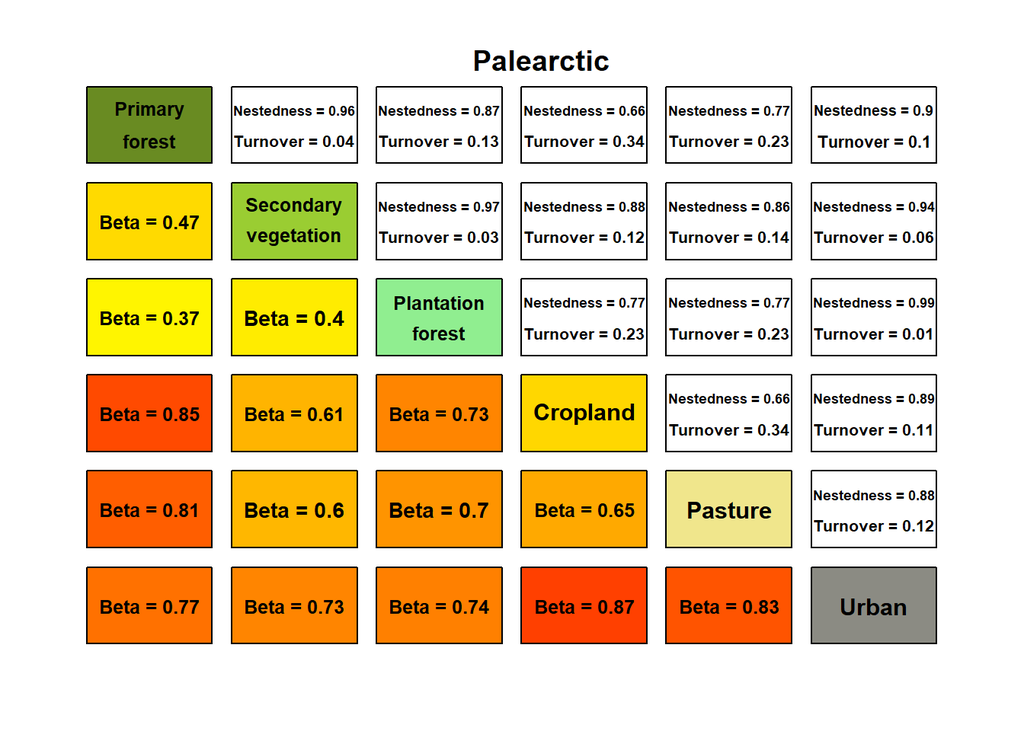

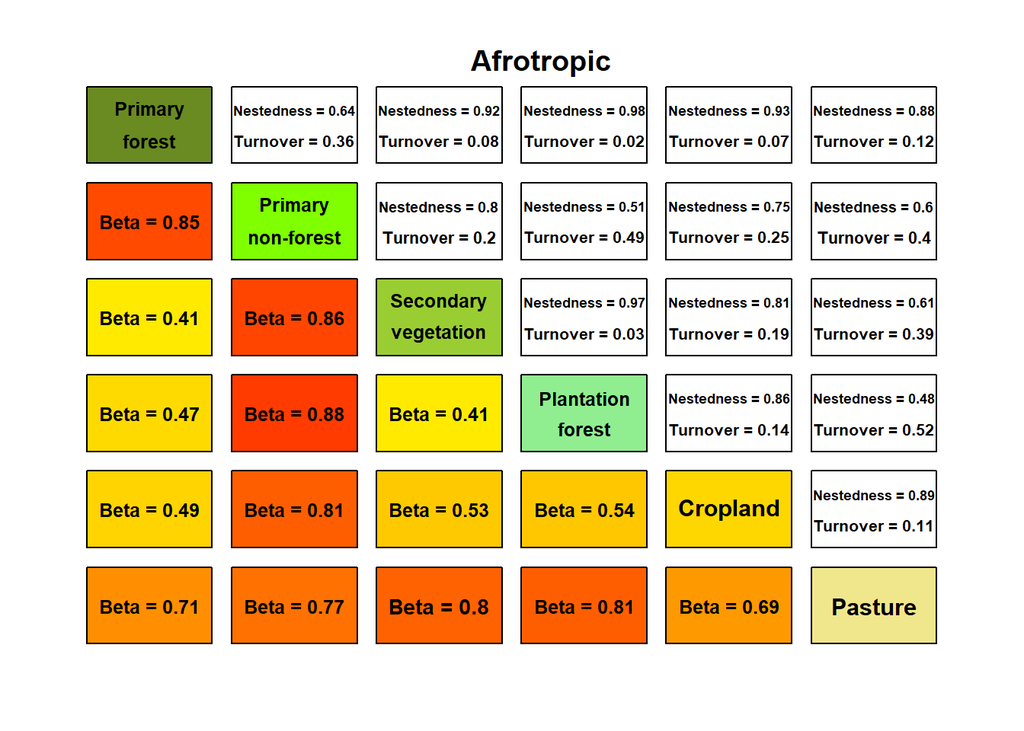

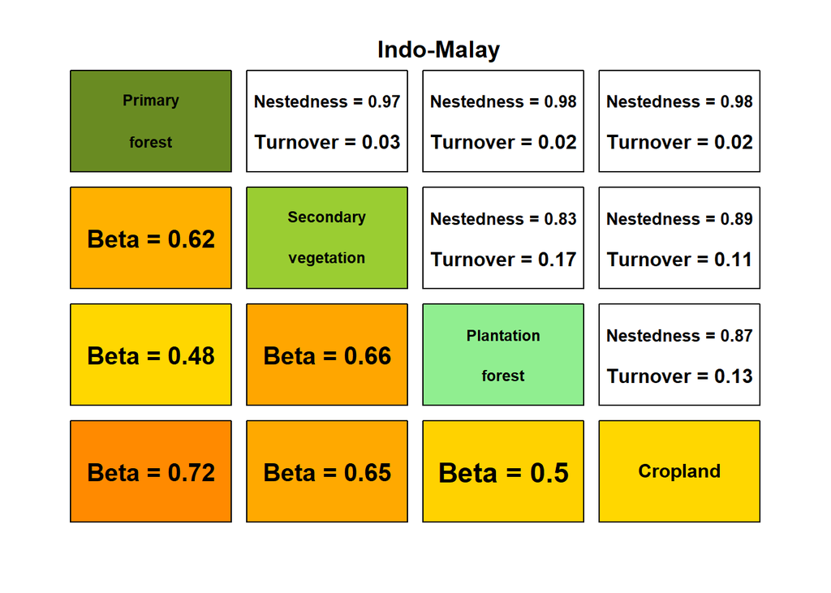

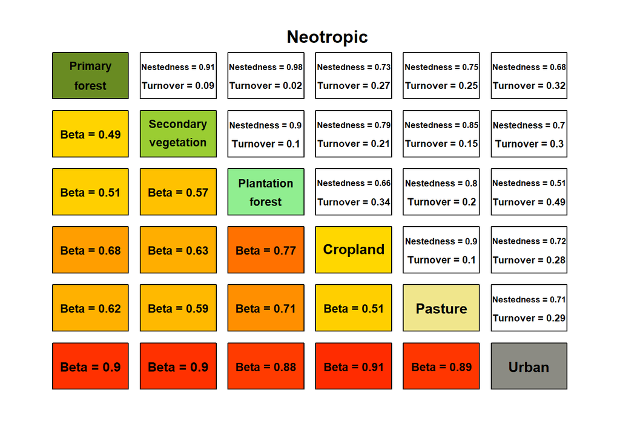

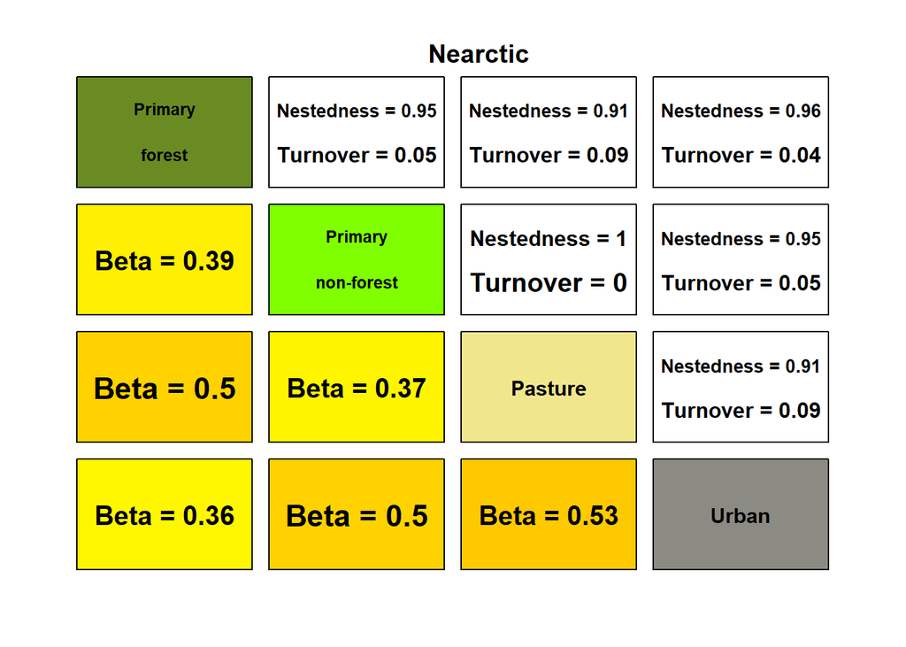

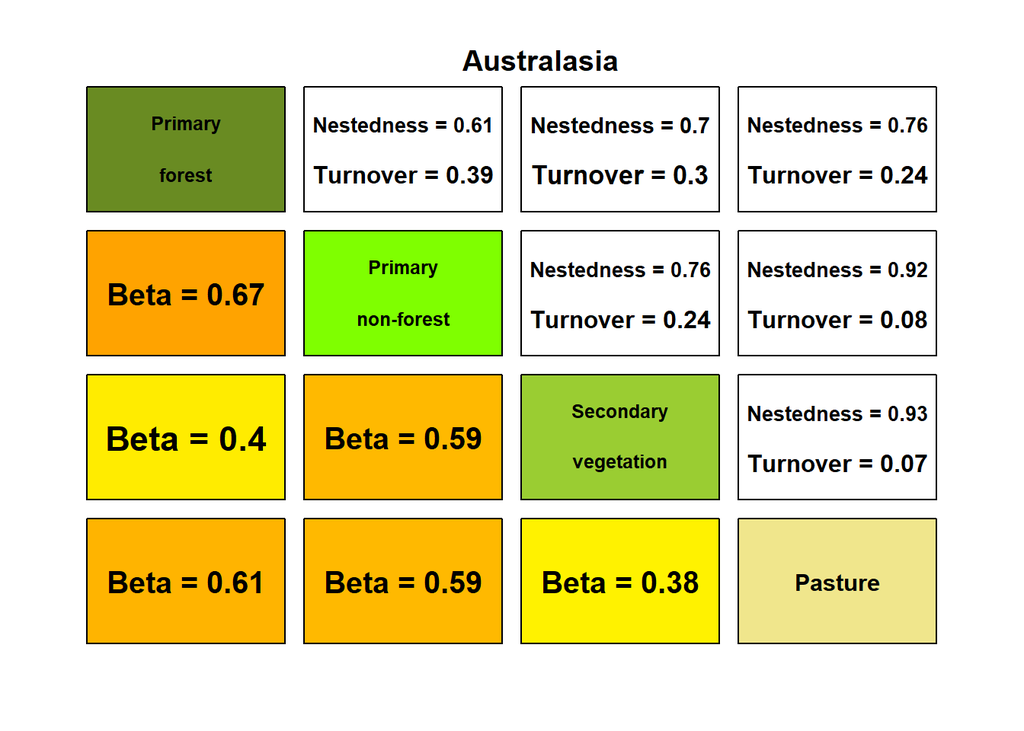

```r
  dissim_list <- list()
  for(r in realms){



      if(r == "Afrotropic"){
      land_uses <- c("Primary forest","Primary non-forest", "Secondary vegetation","Plantation forest","Cropland","Pasture")
    }
    if(r == "Australasia"){
      land_uses <- c("Primary forest","Primary non-forest", "Secondary vegetation", "Pasture")
    }
    if(r == "Indo-Malay"){
      land_uses <- c("Primary forest","Secondary vegetation","Plantation forest","Cropland")
    }
    if(r == "Nearctic"){
      land_uses <- c("Primary forest","Primary non-forest","Pasture", "Urban")
    }
    if(r == "Neotropic"){
      land_uses <- c("Primary forest","Secondary vegetation","Plantation forest","Cropland","Pasture","Urban")
    }
    if(r == "Palearctic"){
      land_uses <- c("Primary forest","Secondary vegetation", "Plantation forest","Cropland","Pasture","Urban")
    }

  LU_combo <- matrix(gtools::combinations(n = length(land_uses), r = 2, v = land_uses,set = TRUE), ncol = 2) %>% data.frame() %>% set_colnames(c("LU1","LU2"))


  array_dimnames <- list(c(land_uses),c(land_uses),c("Dissimilarity","Shared","Not_shared"))
  LU_array <- array(rep(NA,(length(land_uses)^2)*3),dim = c(length(land_uses),length(land_uses),3), dimnames = array_dimnames)

  for(i in 1:nrow(LU_combo)){


    sites_1 <- TPD_LU %>% dplyr::filter(Realm == r, Predominant_habitat == LU_combo[i,"LU1"]) %>% dplyr::distinct(SSBS) %>% pull()
    sites_2 <- TPD_LU %>% dplyr::filter(Realm == r, Predominant_habitat == LU_combo[i,"LU2"]) %>% dplyr::distinct(SSBS) %>% pull()

    dissimilarity <- Calc_dissim(data = PREDICTS_tpds,sites1 = sites_1, sites2 = sites_2)

    LU_array[LU_combo[i,"LU1"],LU_combo[i,"LU2"],"Dissimilarity"] <- dissimilarity[["dissim"]][["dissimilarity"]]
    LU_array[LU_combo[i,"LU1"],LU_combo[i,"LU2"],"Shared"] <- dissimilarity[["dissim"]][["P_shared"]]
    LU_array[LU_combo[i,"LU1"],LU_combo[i,"LU2"],"Not_shared"] <- dissimilarity[["dissim"]][["P_non_shared"]]

    LU_array[LU_combo[i,"LU2"],LU_combo[i,"LU1"],"Dissimilarity"] <- dissimilarity[["dissim"]][["dissimilarity"]]
    LU_array[LU_combo[i,"LU2"],LU_combo[i,"LU1"],"Shared"] <- dissimilarity[["dissim"]][["P_shared"]]
    LU_array[LU_combo[i,"LU2"],LU_combo[i,"LU1"],"Not_shared"] <- dissimilarity[["dissim"]][["P_non_shared"]]



     # TPD_Diff_plot(data = PREDICTS_tpds, sites1 = sites_1, sites2 =sites_2, T1lab = "Locomotion", T2lab = "Foraging",T3lab = "Body",
     #               method = "prob", title = paste("3D_TPD_Plot",LU_combo[i,"LU1"],LU_combo[i,"LU2"], sep = "_"), save = TRUE, file = paste("Outputs/TPD_3D_Plots/",r,"/",LU_combo[i,"LU1"],"_",LU_combo[i,"LU2"],"_difference_", "3dplot.png",sep = ""))
  }

  dissim_list[[r]][["dissim_array"]] <- LU_array


  }

source("Functions/PREDICTS_dissim_plot.R")

for(i in 1:length(dissim_list)){
PREDICTS_dissim_plot(dissim_list[[i]][[1]])
  title(main = paste(names(dissim_list)[i]))
}
```